# Conceptual overview: Principal Components Analysis (PCA)

Updated Oct 09, 2018

## Principal Components Analysis

### motivation

- Often a data set consists of many different variables.
- Principal Components Analysis (PCA) provides a way to focus on the most important aspects of the data.
- Just as the name says, PCA determines the Principal Components of the data set.

## Principal components in genomics

One major use of PCA in genomics is to simplify complex SNP data sets.

Consider a simple data set of two markers, M1 (A/G) and M2 (C/T). We can make a graphical representation of these markers by assigning numeric values to each genotype at each marker.

| M1 | M2 |
| --- | --- |
| AA: 0 | CC: 0 |
| AG: 1 | CT: 1 |
| GG: 2 | TT: 2 |

## Principal components in genomics

We can plot each individual’s genotypes on a 2D scatter plot:

| M1 | M2 |
| --- | --- |
| AA: 0 | CC: 0 |
| AG: 1 | CT: 1 |
| GG: 2 | TT: 2 |

note: points are “jittered” as a visual aid.

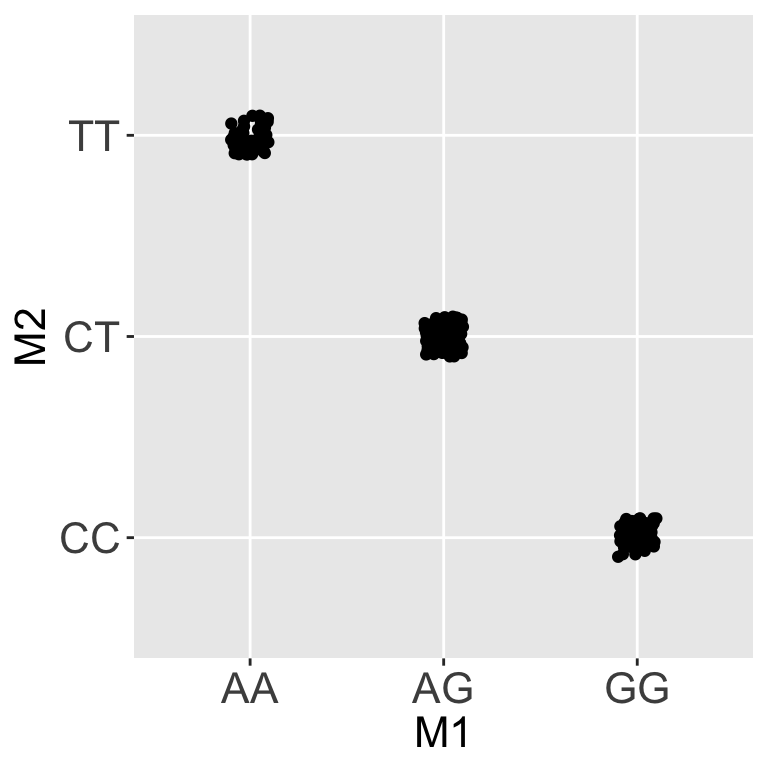

## Principal components in genomics

PCA identifies the vector through the data that contains the largest proportion of variance (i.e. the largest spread of data).

Where would you draw such a line here?

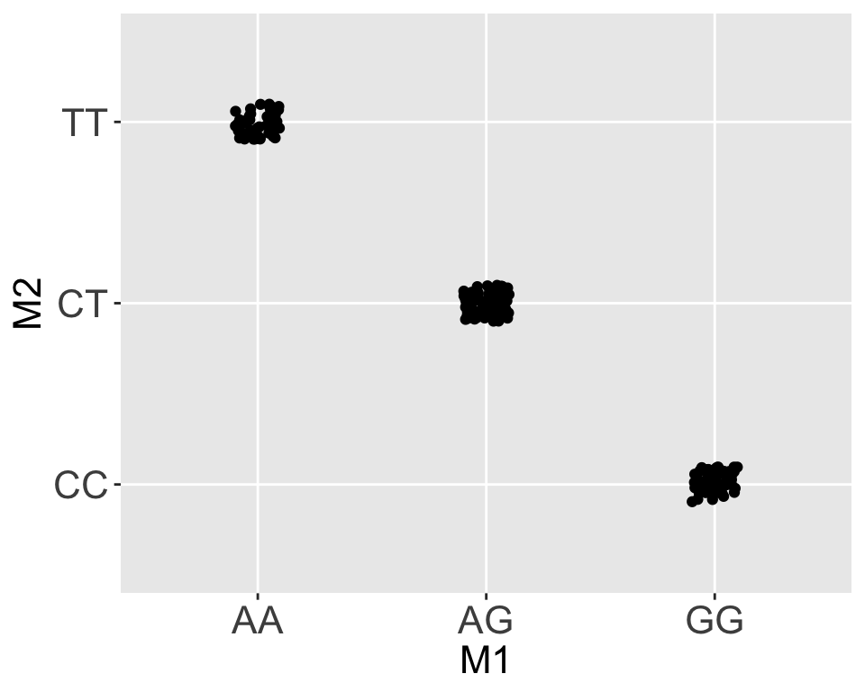

## Principal components in genomics

This vector represents the first principal component (PC1) and the contains the largest variance in the data:

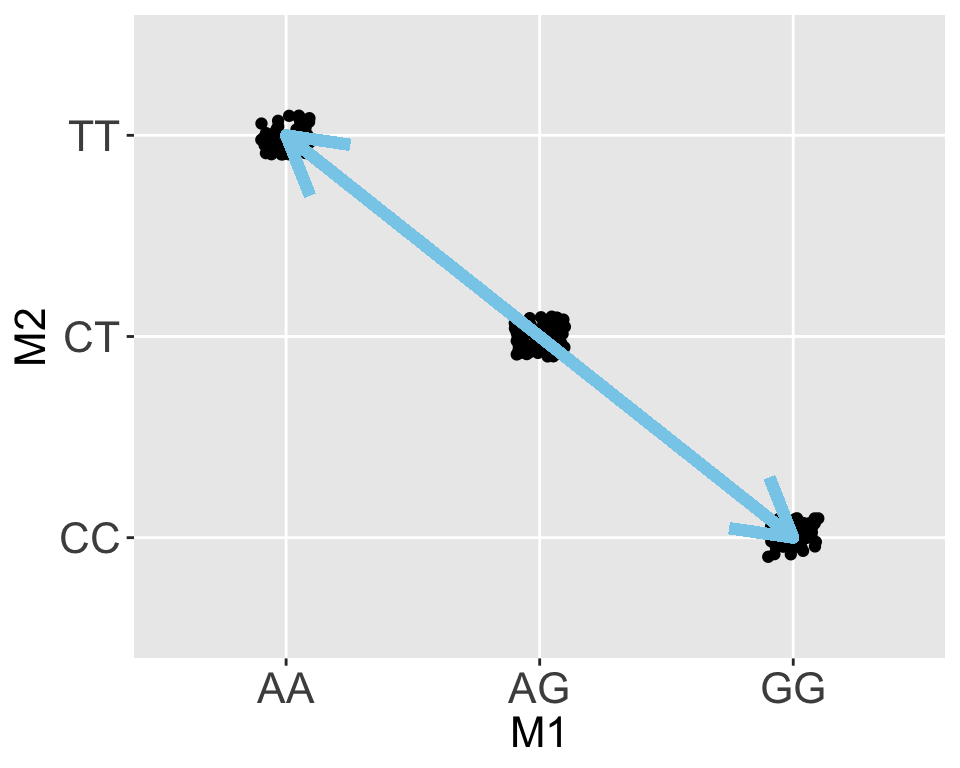

## Principal components in genomics

In this data set the second principal component contains no information.

Thus principal components has simplified a 2D data set to a single dimension.

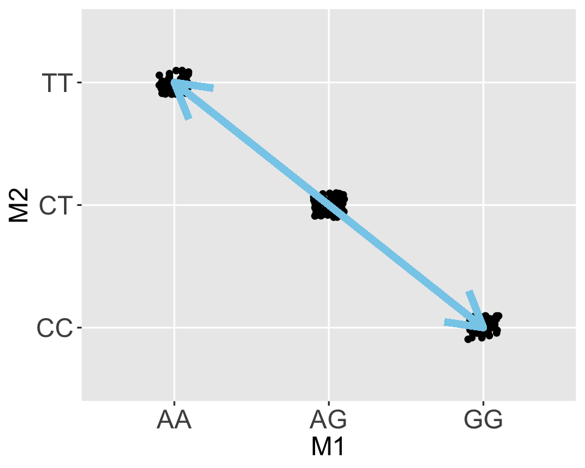

## Principal components in genomics

Consider a new marker, M3:

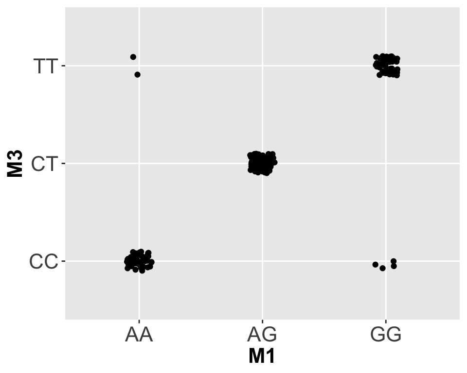

## Principal components in genomics

Where are the first and second principal components here?

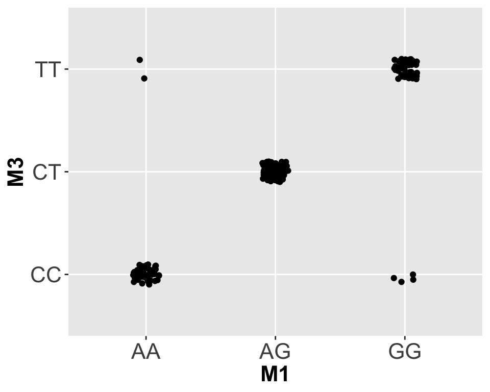

## Principal components in genomics

Where are the first and second principal components here?

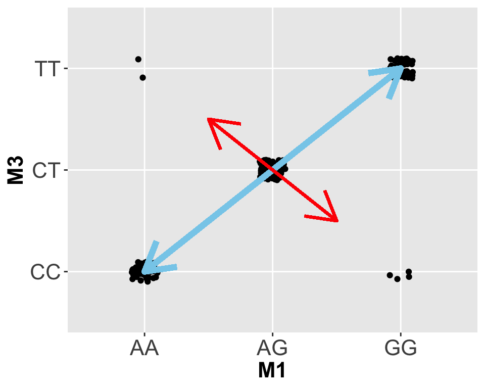

## Principal components in genomics

We can rotate the data to align the plot with the principal components

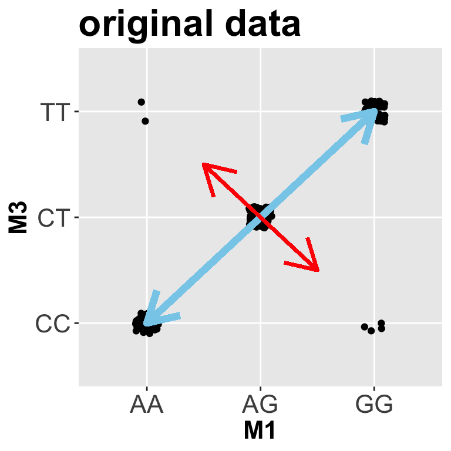

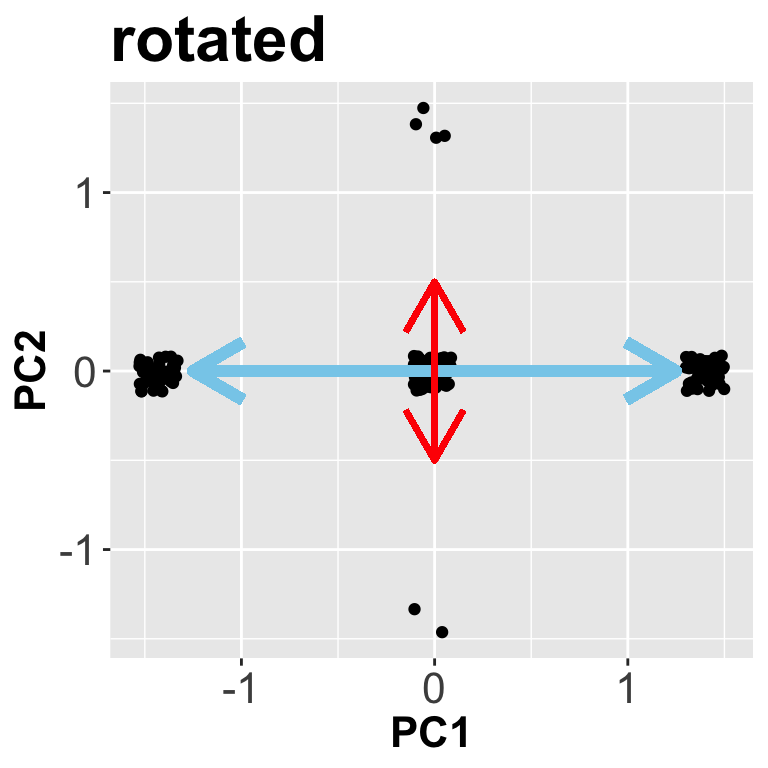

Now we have a single axis that represents the majority of the variation in the data, and a second axis that accounts for the remainder.

## Three SNPs–First View

What if there are 3 SNPs?

Now we have 3 dimensions

In this view it appears that most of the variance in along a single vector.

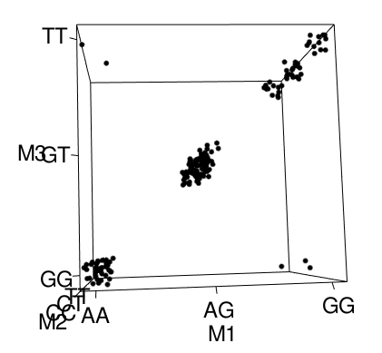

first view

## Three SNPs–live 3D view

[interactive chart not shown]

You must enable Javascript to view this page properly.

demo live rotation of data cube

## Three SNPs–Second View

Changing rotation alters our interpretation of the data.

Now we see that we could draw 2 principal components that each would capture a fair bit of variance

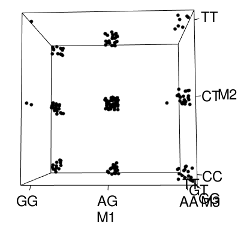

second view

## Three SNPs–Third View

Changing rotation alters our interpretation of the data.

This rotation shows a third axis of variation.

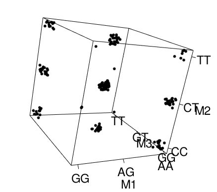

third view

## PCA analysis of 3 SNPs

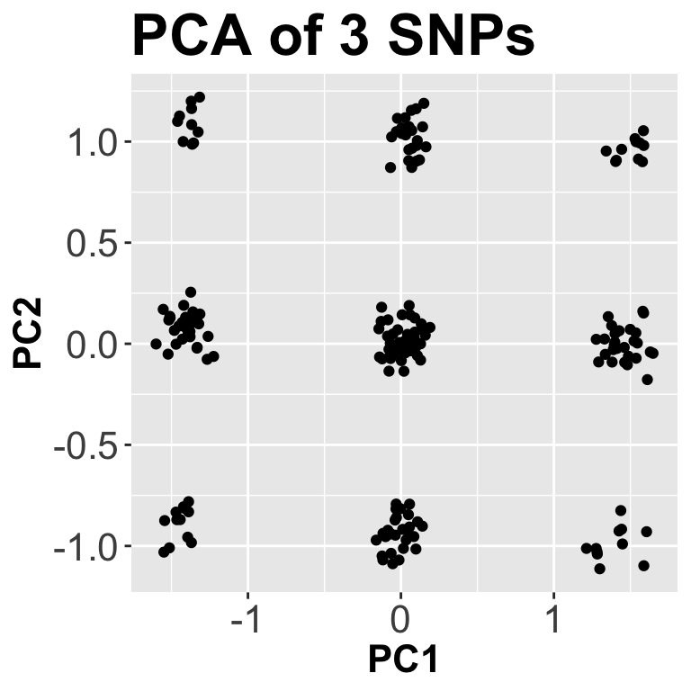

What do these PCs represent?

|  | PC1 | PC2 | PC3 |
| --- | --- | --- | --- |
| M1 | -0.71 | 0.01 | -0.71 |
| M2 | -0.03 | -1.00 | 0.01 |
| M3 | -0.71 | 0.03 | 0.71 |

- PC1 captures co-variation at M1 and M3
- PC2 captures variation at M2
- PC3 captures opposite variation at M1 and M3

## PCA analysis of 3 SNPs

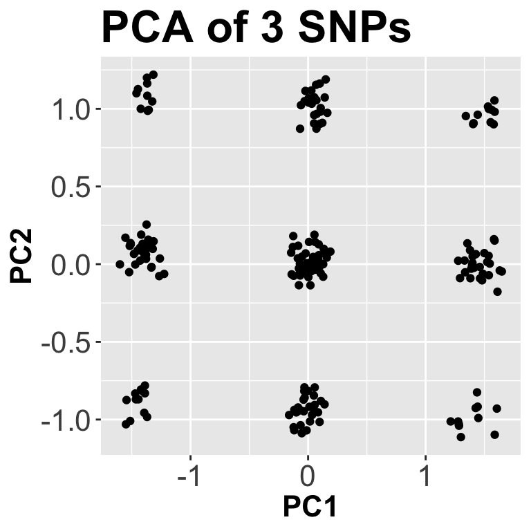

How much variation is explained by each PC?

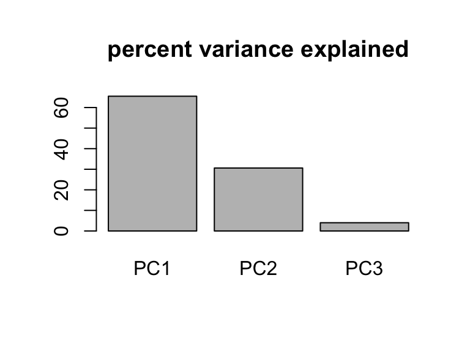

PC1 and PC2 capture almost all of the variance. We have converted our 3D data set into a 2D data set

## PCA: many dimensions

- As you have seen in these examples, each SNP column can be considered a dimension of data.
- In the Li et al. paper there are 650,000 SNPs = 650,000 dimensions!
- By applying PCA the data is partioned such that the most informative aspects are represnted in the first PCs

## PCA Summary

- Genomics data is typically highly dimensional.
- There is often redundancy in the data.
- PCA allows rotation and rescaling of the data so that we can focus on a smaller set of variables that contain the majority of the information.
- PCA enables 2D visualization of multi-dimensional datasets (for example by plotting the first and second PCs against one another).

## PCA vs MDS

A related technique is multi-dimensional scaling (MDS).

- In PCA the final number of components is the same as the starting number of dimensions, but the information has been shifted towards a fewer number of dimensions.
- In MDS the data is rescaled and rotated to project it into a fixed number of dimensions (typically 2).

## MDS

Determines the optimal projection to display the data in 2D

**poor rotation**

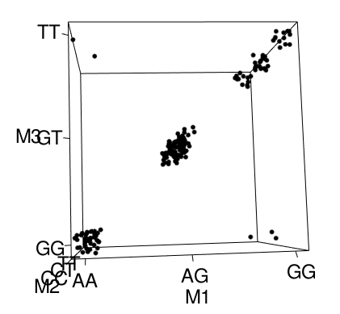

**good rotation**

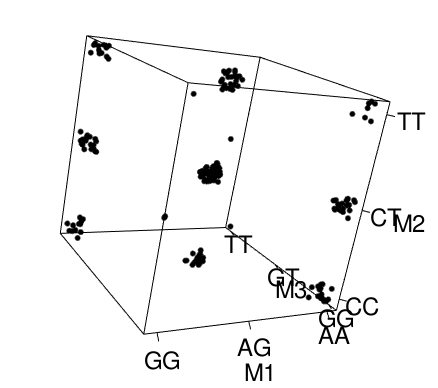